# Final Project

Tatum Good, Jace Higa, Kendall Leonard

## Scrub-a-dub-dub (AKA Cleaning the Data)

- A lot of percentages in this data
  - meaning that a lot of numeric data was being seen as textual, making any meaningful feature building next to impossible
- So we chopped off the percentages!
  - Yay! Workable data!

## Features We Used

- bel_94_perc_BOM
- high_revenue
- log_revenue
- interaction_cost_units
- high_volume
- src_www
- direct
- form
- main_component
- june

## A detailed look: bel_94_perc_BOM

- Stands for ‘Below the 94th Percentile BOM (Bill of Materials)’
- Bill of Materials: A price that consists of all materials needed to assemble a product.
- The less the materials cost, the more profit is possible.
- Why the 94th percentile?
  - Tested many percentiles but the 94th ended up lowering our RMSE the most.

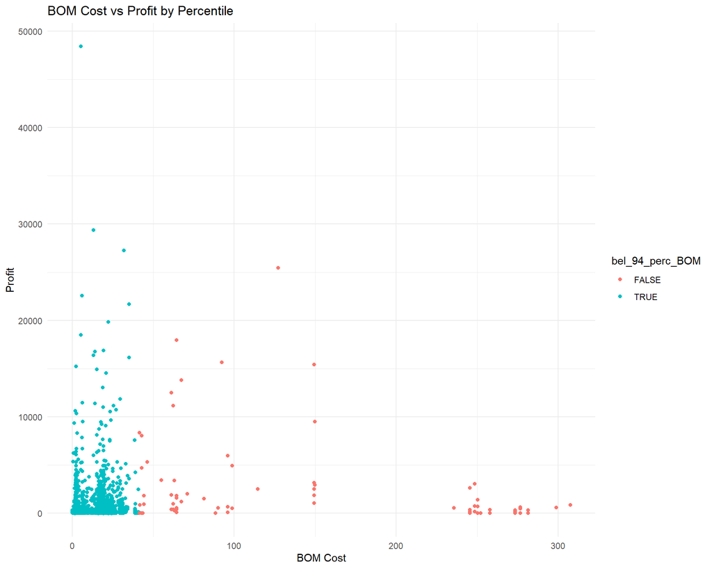

## A detailed look: high_revenue_products

- Used the 94th percentile as well.
  - Figured that the more potential revenue you make off of a product the more profit is available.
  - Think selling a house vs. selling hotdogs

## A detailed look: log_revenue

- Revenue often has a skewed distribution, where some products generate much higher sales than others. By applying a logarithmic transformation, we make the distribution more symmetric and reduce the impact of extreme values, helping the model generalize better.

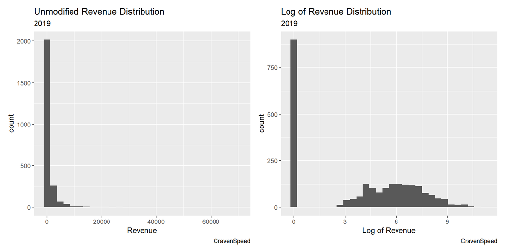

## A detailed look: interaction_cost_units

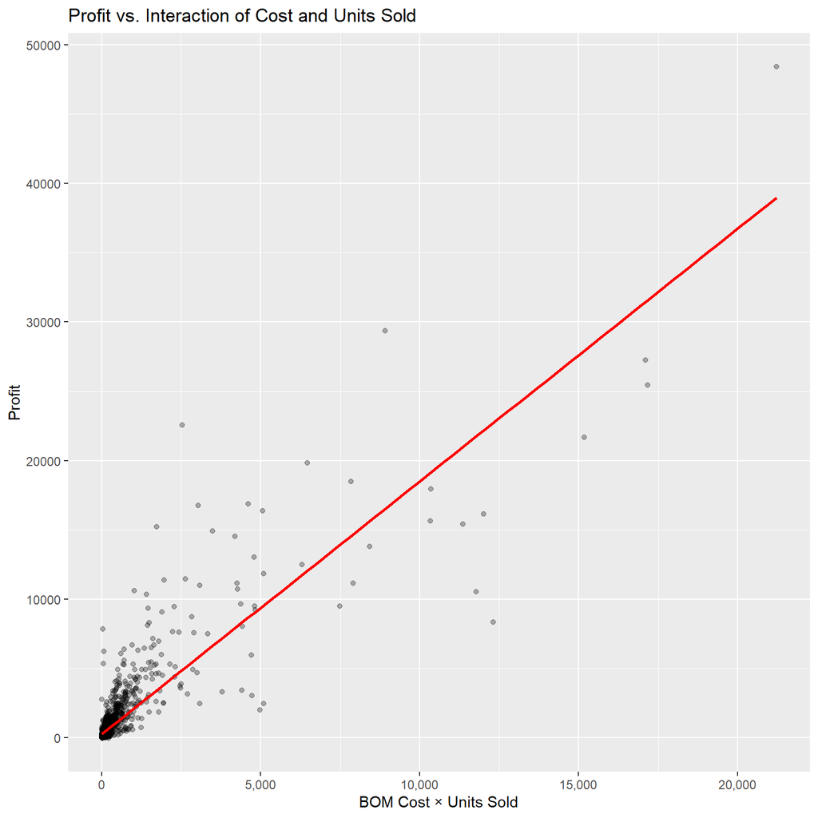

## A detailed look: high_volume

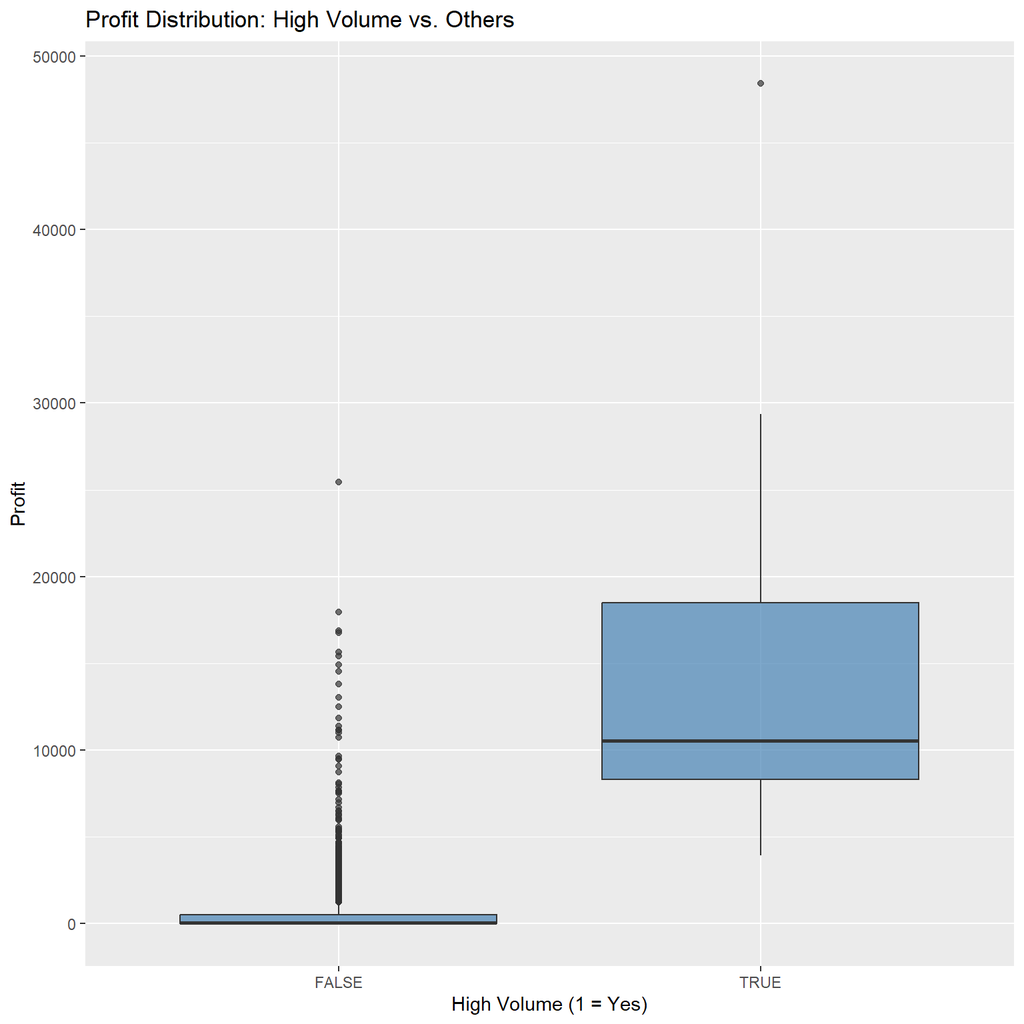

## A detailed look: direct

- Indicates if a product had over 90% of its sales via Direct Sales.
- Why we chose it:
  - Selling direct often means higher profit margins (fewer middlemen).
  - This could significantly influence profit and help the model avoid underpredicting for high-margin products.

## A detailed look: form

- Binary flag for whether the main manufacturing process was “Form”.
- Why this matters:
  - The manufacturing method likely affects production cost and complexity.
  - Certain methods might be more efficient or scalable, thus affecting profit margins.

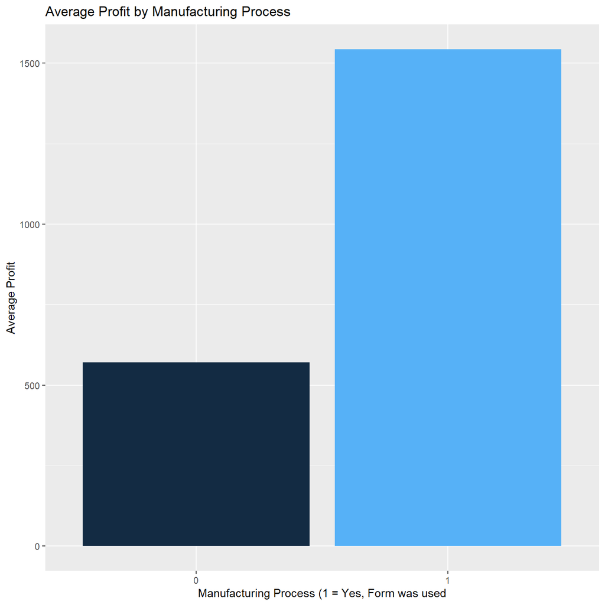

## A detailed look: main_component

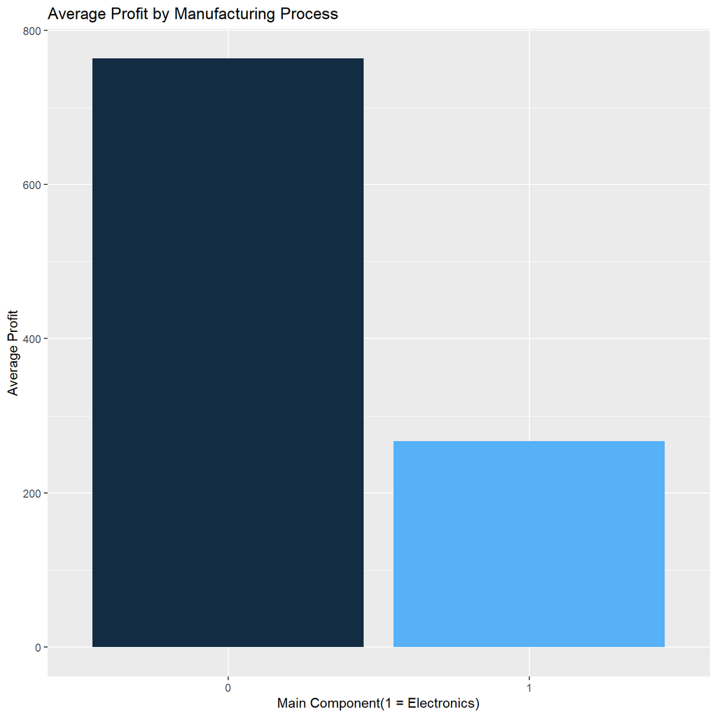

## A detailed look: june

- Flag for whether the product’s June column was greater than 3 (likely a proxy for year of introduction or recency).
- Why we kept it:
  - Newer products might be in the early stages of the product life cycle, where profits vary widely.
  - Including this helps the model adjust for maturity or freshness of products in predicting profits.

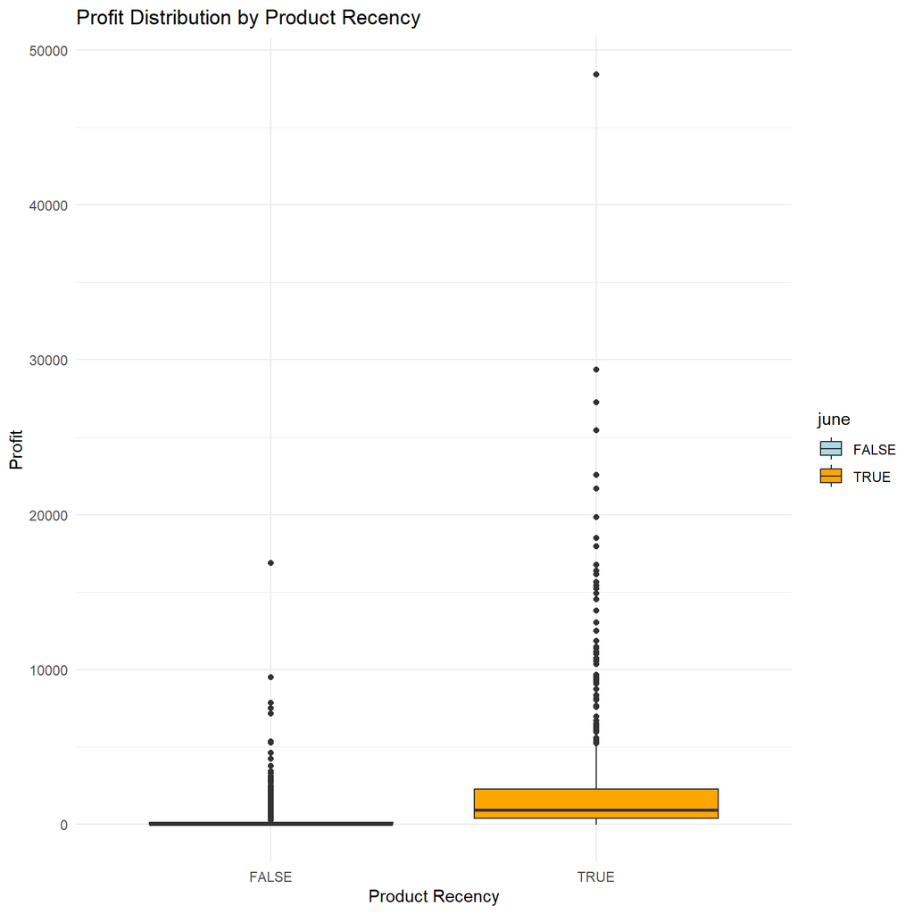

## The Big Reveal: RMSE

```
[1] 887.6885
```

- In this context, an RMSE (Root Mean Squared Error) value of 887.6885 means that, on average, your model’s predicted profit is off by about $887.69 compared to the actual profit.
- Since we’re predicting profit in dollars, RMSE is measured in the same units. So:
  - If our model predicts a product will make $5,000 in profit, it’s typically off by around $887.69 in either direction

Thank you!